# Claude로 지식 그래프 만들기

## 엔티티 해소

원시 추출 결과에는 겹치는 언급들이 있습니다. "NASA"와 "National Aeronautics and Space Administration", "Neil Armstrong"과 "Armstrong", 어쩌면 "the Moon"과 "Moon"까지요. 여기서 바로 그래프를 만들면 같은 개념이 서로 끊긴 노드로 쪼개진 엉망인 결과가 나옵니다.

전통적인 방식은 문자열 유사도(편집 거리, 토큰 자카드)에 블로킹 규칙을 더해 씁니다. 오타에는 통하지만 "Edwin Aldrin"과 "Buzz Aldrin"에는 실패합니다. 문자가 하나도 겹치지 않는데 같은 사람을 가리키는 두 이름이니까요.

대신 우리는 추출 단계에서 얻은 한 줄 설명을 판별 맥락으로 삼아, 유형별로 엔티티를 묶어 달라고 Claude에 요청합니다. 이 설명이 중요합니다. "Armstrong — 달을 처음 밟은 사람"과 "Armstrong — 재즈 트럼펫 연주자"는 이름이 같지만 합쳐져서는 안 됩니다.

```python
class Cluster(BaseModel):
    canonical: str
    aliases: list[str]


class ResolvedClusters(BaseModel):
    clusters: list[Cluster]


RESOLVE_PROMPT = """Below are {entity_type} entities extracted from several documents. Some are different surface forms of the same real-world entity.

<entities>
{entity_list}
</entities>

Cluster them. Each input name must appear in exactly one cluster's aliases list. Entities that are genuinely distinct get their own single-element cluster. Use the descriptions to avoid merging entities that merely share a name. The canonical name should be the most complete, unambiguous form."""


def resolve(entity_type: str, entities: list[dict]) -> list[Cluster]:
    unique = {}
    for e in entities:
        unique.setdefault(e["name"], e["description"])
    entity_list = "\n".join(f"- {name}: {desc}" for name, desc in unique.items())

    response = client.messages.parse(
        model=SYNTHESIS_MODEL,
        max_tokens=2048,
        messages=[
            {
                "role": "user",
                "content": RESOLVE_PROMPT.format(entity_type=entity_type, entity_list=entity_list),
            }
        ],
        output_format=ResolvedClusters,
    )
    return response.parsed_output.clusters
```

눈여겨볼 실패 양상이 둘 있습니다. 첫째, Claude가 어떤 클러스터에도 넣지 않은 원시 이름은 `alias_to_canonical`에 항목이 없어 그래프에서 조용히 사라집니다. 실제 해소기라면 매칭되지 않은 이름에 대해 단일 원소 클러스터로 폴백해 아무것도 잃지 않게 해야 합니다. 둘째, 해소기가 **과도하게 합칠** 수 있습니다. "Gemini 12" 같은 특정 임무가 설명이 겹친다는 이유로 더 넓은 "Project Gemini"에 흡수될 수 있습니다. 첫 번째는 노드를 잃고, 두 번째는 정밀도를 잃습니다. 아래 출력에서 둘 다 확인해 볼 만합니다.

```python
alias_to_canonical = {}
canonical_info = {}

for etype in ENTITY_TYPES:
    entities_of_type = [e for e in raw_entities if e["type"] == etype]
    if not entities_of_type:
        continue
    try:
        clusters = resolve(etype, entities_of_type)
    except anthropic.APIError as e:
        print(f"Resolve failed for {etype}: {e}; treating each name as its own cluster")
        clusters = [
            Cluster(canonical=n, aliases=[n]) for n in {x["name"] for x in entities_of_type}
        ]
    for cluster in clusters:
        canonical_info[cluster.canonical] = {"type": etype, "aliases": cluster.aliases}
        for alias in cluster.aliases:
            alias_to_canonical[alias] = cluster.canonical

before = len({e["name"] for e in raw_entities})
after = len(canonical_info)
print(f"Entity resolution: {before} unique names → {after} canonical entities\n")

for canonical, info in sorted(canonical_info.items()):
    aliases = [a for a in info["aliases"] if a != canonical]
    alias_str = f"  (also: {', '.join(aliases)})" if aliases else ""
    print(f"{info['type']:<14} {canonical}{alias_str}")
```

```
Entity resolution: 24 unique names → 22 canonical entities

EVENT          Apollo 11
EVENT          Apollo program
PERSON         Buzz Aldrin  (also: Edwin Aldrin)
ORGANIZATION   Cape Canaveral Space Force Station
PERSON         Dwight D. Eisenhower
EVENT          Gemini 12
PERSON         Jim Lovell
PERSON         John F. Kennedy
ORGANIZATION   John F. Kennedy Space Center
ARTIFACT       Launch Complex 39
LOCATION       Merritt Island
PERSON         Michael Collins
LOCATION       Moon
ORGANIZATION   NASA
PERSON         Neil Alden Armstrong  (also: Neil Armstrong)
EVENT          Project Gemini
EVENT          Project Mercury
ARTIFACT       Saturn V
ARTIFACT       Skylab
EVENT          Skylab program
EVENT          Space Shuttle program
ORGANIZATION   U.S. Congress
```

## 그래프 구성하기

깔끔한 별칭 맵을 얻었으니 모든 관계의 양 끝을 정규 형태로 바꿔 NetworkX에 적재합니다. `MultiDiGraph`를 쓰는 이유는 두 엔티티가 여러 서로 다른 술어로 연결될 수 있고("~에서 발사됨", "~가 운영함"), 방향이 중요하기 때문입니다("Armstrong이 아폴로 11호를 지휘했다"는 "아폴로 11호가 Armstrong을 지휘했다"와 다른 엣지입니다).

각 노드는 자신의 유형, 자신을 언급한 문서 집합, 언급 횟수를 갖습니다. 각 엣지는 술어와 출처 문서를 갖습니다.

```python
G = nx.MultiDiGraph()

for e in raw_entities:
    canonical = alias_to_canonical.get(e["name"])
    if canonical is None:
        continue
    if canonical not in G:
        G.add_node(
            canonical,
            type=canonical_info[canonical]["type"],
            description=e["description"],
            source_docs=[],
            mentions=0,
        )
    G.nodes[canonical]["source_docs"].append(e["source_doc"])
    G.nodes[canonical]["mentions"] += 1

for r in raw_relations:
    src = alias_to_canonical.get(r["source"])
    tgt = alias_to_canonical.get(r["target"])
    if src and tgt and src != tgt:
        G.add_edge(src, tgt, predicate=r["predicate"], source_doc=r["source_doc"])

for n in G.nodes:
    G.nodes[n]["source_docs"] = sorted(set(G.nodes[n]["source_docs"]))

print(f"Graph: {G.number_of_nodes()} nodes, {G.number_of_edges()} edges")
print(f"Connected components: {nx.number_weakly_connected_components(G)}")
print("\nMost connected entities:")
for node, deg in sorted(G.degree(), key=lambda x: -x[1])[:5]:
    print(f"  {node:<35} degree {deg:>2}  ({G.nodes[node]['type']})")
```

```
Graph: 22 nodes, 34 edges
Connected components: 1

Most connected entities:
  Apollo program                      degree  9  (EVENT)
  Apollo 11                           degree  9  (EVENT)
  John F. Kennedy Space Center        degree  7  (ORGANIZATION)
  Neil Alden Armstrong                degree  5  (PERSON)
  Buzz Aldrin                         degree  5  (PERSON)
```

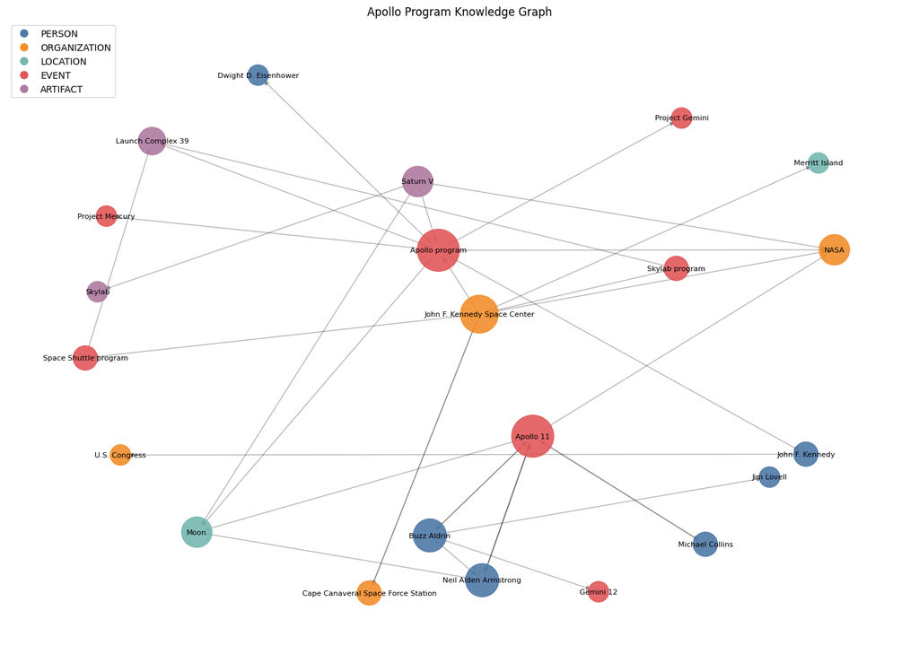

```python
COLOR = {
    "PERSON": "#4e79a7",
    "ORGANIZATION": "#f28e2c",
    "LOCATION": "#76b7b2",
    "EVENT": "#e15759",
    "ARTIFACT": "#af7aa1",
}

plt.figure(figsize=(14, 10))
pos = nx.spring_layout(G, k=1.5, seed=42)
node_colors = [COLOR[G.nodes[n]["type"]] for n in G.nodes]
node_sizes = [300 + 200 * G.degree(n) for n in G.nodes]

nx.draw_networkx_nodes(G, pos, node_color=node_colors, node_size=node_sizes, alpha=0.9)
nx.draw_networkx_labels(G, pos, font_size=8)
nx.draw_networkx_edges(G, pos, alpha=0.3, arrows=True, arrowsize=10)

handles = [
    plt.Line2D([0], [0], marker="o", color="w", markerfacecolor=c, markersize=10, label=t)
    for t, c in COLOR.items()
    if any(G.nodes[n]["type"] == t for n in G.nodes)
]
plt.legend(handles=handles, loc="upper left")
plt.title("Apollo Program Knowledge Graph")
plt.axis("off")
plt.tight_layout()
plt.show()
```

노드 크기는 차수에 비례합니다. 허브가 코퍼스를 하나로 묶어 주는 엔티티입니다. 색은 유형을 나타냅니다. 그래프가 대부분 한 가지 색이라면 코퍼스가 좁은 것이고, 색이 잘 섞여 있다면 추출기가 사람·장소·사물을 두루 찾아내고 있다는 뜻입니다. 연결 요소가 하나라면 엔티티 해소가 제 몫을 한 것입니다. 섬처럼 흩어져 있다면 합쳐졌어야 할 변형들이 합쳐지지 않았다는 신호입니다.

## 엔티티 요약

지금 각 노드는 자신을 처음 언급한 문서에서 온 한 줄 설명만 갖고 있습니다. 여러 문서에 등장하는 허브 노드라면 훨씬 잘할 수 있습니다. 모든 언급을 모으고, 그래프 이웃을 맥락으로 더해, Claude가 제대로 된 프로필을 종합하게 하는 것입니다.

레이블의 그래프를 지식의 그래프로 바꾸는 단계입니다. 이 요약이 검색 결과에 노출하거나 후속 질의응답에 넘길 노드 내용이 됩니다.

```python
class TimeRange(BaseModel):
    start: str  # YYYY or YYYY-MM, or "unknown"
    end: str  # YYYY or YYYY-MM, or "ongoing"


class EntityProfile(BaseModel):
    summary: str
    key_facts: list[str]
    time_range: TimeRange


SUMMARIZE_PROMPT = """Generate a knowledge-graph profile for this entity.

Entity: {name} ({etype})

Source excerpts mentioning this entity:
{excerpts}

Known relations in the graph:
{relations}

Write a 2-3 paragraph factual summary synthesized from the excerpts, resolving any contradictions by preferring the most specific claim. Include 3-5 atomic key facts, each traceable to the sources. For the time range, use YYYY or YYYY-MM format, or "unknown"/"ongoing" where appropriate. Do not invent facts not supported by the excerpts."""


def summarize_entity(name: str) -> EntityProfile:
    # Reads module-level G and documents built earlier in the notebook.
    docs_with_entity = G.nodes[name]["source_docs"]
    excerpts = "\n\n".join(
        f"[{d['title']}]\n{d['text']}" for d in documents if d["title"] in docs_with_entity
    )
    relations = (
        "\n".join(
            f"- {name} --{d['predicate']}--> {tgt}" for _, tgt, d in G.out_edges(name, data=True)
        )
        + "\n"
        + "\n".join(
            f"- {src} --{d['predicate']}--> {name}" for src, _, d in G.in_edges(name, data=True)
        )
    )

    response = client.messages.parse(
        model=SYNTHESIS_MODEL,
        max_tokens=1500,
        messages=[
            {
                "role": "user",
                "content": SUMMARIZE_PROMPT.format(
                    name=name, etype=G.nodes[name]["type"], excerpts=excerpts, relations=relations
                ),
            }
        ],
        output_format=EntityProfile,
    )
    return response.parsed_output
```

```python
hub_nodes = [n for n, _ in sorted(G.degree(), key=lambda x: -x[1])[:3]]

for node in hub_nodes:
    profile = summarize_entity(node)
    G.nodes[node]["profile"] = profile.model_dump()
    print(f"═══ {node} ═══")
    print(profile.summary)
    print(f"\nTime range: {profile.time_range.start} – {profile.time_range.end}")
    print("Key facts:")
    for fact in profile.key_facts:
        print(f"  • {fact}")
    print()
```

```
═══ Apollo program ═══
The Apollo program, also known as Project Apollo, was a United States human spaceflight program led by NASA, primarily aimed at landing humans on the Moon. It was conceived in 1960 during the presidency of Dwight D. Eisenhower as a three-person spacecraft program, building upon the foundations laid …

The Apollo program successfully landed the first humans on the Moon in 1969. It relied on the Saturn V, a super heavy-lift launch vehicle developed by NASA specifically for the program, which flew from 1967 to 1973 and supported nine crewed flights to the Moon. Launch operations were conducted from …

Time range: 1960 – 1973
Key facts:
  • The Apollo program was conceived in 1960 under the presidency of Dwight D. Eisenhower as a three-person spacecraft program.
  • Apollo was dedicated to President John F. Kennedy's goal of landing a man on the Moon, as stated in his address to Congress on May 25, 1961.
  • The Apollo program successfully landed the first humans on the Moon in 1969.
  • The Saturn V rocket, developed under the Apollo program, flew from 1967 to 1973 and supported nine crewed lunar flights.
  • Launch operations for the Apollo program were carried out from Kennedy Space Center Launch Complex 39.
```

```
═══ Apollo 11 ═══
Apollo 11 was the American spaceflight that achieved the historic first crewed lunar landing, representing the fifth crewed mission of NASA's Apollo program. The mission was commanded by Neil Armstrong, with Michael Collins serving as Command Module Pilot and Edwin "Buzz" Aldrin as Lunar Module Pilo…

During the mission, Neil Armstrong became the first person to walk on the Moon, followed by Buzz Aldrin, making him the second. Michael Collins remained in the Command Module in lunar orbit. The mission stands as a landmark achievement in human spaceflight history. As of 2025, Buzz Aldrin is the las…

Time range: 1969 – 1969
Key facts:
  • Apollo 11 was the fifth crewed mission of NASA's Apollo program and the first to land humans on the Moon.
  • The crew consisted of Commander Neil Armstrong, Command Module Pilot Michael Collins, and Lunar Module Pilot Buzz Aldrin.
  • Neil Armstrong was the first person to walk on the Moon, with Buzz Aldrin becoming the second.
  • All three Apollo 11 crew members were on their second and final spaceflights.
  • Buzz Aldrin is the last surviving member of the Apollo 11 crew, following the deaths of Armstrong in 2012 and Collins in 2021.
```

```
═══ John F. Kennedy Space Center ═══
The John F. Kennedy Space Center (KSC) is a NASA field center situated on Merritt Island, Florida, on the east coast of the state. It is one of ten field centers operated by NASA and has served as the agency's primary launch center for American spaceflight, research, and technology since 1968. Launc…

KSC operates in close proximity to Cape Canaveral Space Force Station (CCSFS), with the two entities maintaining a collaborative relationship. Their management teams work closely together, share resources, and operate facilities on each other's property, reflecting a high degree of integration betwe…

Time range: 1968 – ongoing
Key facts:
  • John F. Kennedy Space Center is located on Merritt Island, Florida, and is one of ten NASA field centers.
  • KSC has been NASA's primary launch center for American spaceflight, research, and technology since 1968.
  • Launch operations for the Apollo, Skylab, and Space Shuttle programs were carried out from KSC's Launch Complex 39.
  • KSC is adjacent to Cape Canaveral Space Force Station, and the two entities share resources and operate facilities on each other's property.
```

## 그래프 질의하기

지식 그래프를 만드는 보람은 다중 홉 추론에 있습니다. 한 문서에 함께 나타나지 않는 사실들을 이어야 답할 수 있는 질문 말이죠. "아폴로 11호에 탑승한 사람들과 연결된 장소는 어디인가?"에 답하려면, 추출기가 한 문서에서 사람→임무 엣지를, 다른 문서에서 사람→장소 엣지를 찾아냈어야 하고, 해소기가 사람 노드를 통합해 그 엣지들이 실제로 만나게 했어야 합니다.

관련 부분 그래프를 트리플로 직렬화해 Claude가 그 위에서 추론하게 합니다. 비교를 위해 먼저 그래프 맥락 없이 같은 질문을 던져 봅니다.

```python
def serialize_subgraph(center: str, hops: int = 2) -> str:
    nodes = {center}
    frontier = {center}
    for _ in range(hops):
        nxt = set()
        for n in frontier:
            nxt |= set(G.successors(n)) | set(G.predecessors(n))
        frontier = nxt - nodes
        nodes |= frontier
    sub = G.subgraph(nodes)
    lines = [f"({s}) --[{d['predicate']}]--> ({t})" for s, t, d in sub.edges(data=True)]
    return "\n".join(sorted(set(lines)))


def ask(question: str, graph_context: str | None = None) -> str:
    if graph_context is not None:
        prompt = f"""Answer using only the knowledge graph below. Cite the specific edges that support your answer.

<graph>
{graph_context}
</graph>

Question: {question}"""
    else:
        prompt = question
    response = client.messages.create(
        model=SYNTHESIS_MODEL,
        max_tokens=500,
        messages=[{"role": "user", "content": prompt}],
    )
    text_block = next((b for b in response.content if b.type == "text"), None)
    if text_block is None:
        raise ValueError(f"No text block in response (stop_reason={response.stop_reason})")
    return text_block.text
```

```python
center = next((n for n in G.nodes if "Apollo" in n), hub_nodes[0])
print(f"Querying 2-hop neighborhood of: {center}\n")
subgraph = serialize_subgraph(center, hops=2)

question = "Which locations are connected to people who were part of Apollo 11, and how?"

print("WITHOUT graph context:")
print(ask(question))
print("\n" + "─" * 60 + "\n")
print("WITH graph context:")
print(ask(question, subgraph))
```

```
Querying 2-hop neighborhood of: Apollo program

WITHOUT graph context:
```

```
# Locations Connected to Apollo 11 Personnel

## Neil Armstrong (Commander)

- **Wapakoneta, Ohio** – birthplace and hometown; the **Neil Armstrong Air & Space Museum** is located there
- **Purdue University, Indiana** – where he studied aeronautical engineering
- **Edwards Air Force Base, California** – where he worked as a test pilot
- **Cincinnati, Ohio** – where he lived later in life and died (2012)

## Buzz Aldrin (Lunar Module Pilot)

- **Montclair, New Jersey** – birthplace
- **West Point, New York** – attended the U.S. Military Academy
- **MIT, Massachusetts** – earned his doctorate in astronautics
- **Los Angeles area** – longtime residence after NASA career

## Michael Collins (Command Module Pilot)

- **Rome, Italy** – birthplace (son of a U.S. Army officer)
- **Washington, D.C.** – attended school; later directed the **Smithsonian National Air and Space Museum**
- **West Point** – attended the Military Academy

## Shared/Mission Locations

- **Kennedy Space Center, Florida** – launch site (July 16, 1969)
- **Houston, Texas** – Mission Control and astronaut training (Johnson Space Center)
- **Pacific Ocean** – splashdown and recovery site
- **Honolulu, Hawaii** – where the crew was initially quarantined aboard the USS Hornet

Would you like more detail on any individual?

────────────────────────────────────────────────────────────

WITH graph context:
```

```
## Locations Connected to Apollo 11 Personnel

Based on the knowledge graph, here is what can be determined about people connected to Apollo 11 and their location relationships:

### Neil Alden Armstrong
Neil Armstrong is the person directly identified as part of Apollo 11, supported by:
- **(Apollo 11) --[commanded by]--> (Neil Alden Armstrong)**
- **(Neil Alden Armstrong) --[commanded]--> (Apollo 11)**

He is connected to the following location:

#### 🌕 The Moon
- **(Neil Alden Armstrong) --[walked on]--> (Moon)**

This is the only **direct** person-to-location edge in the graph for an Apollo 11 crew member.

---

### Indirect Location Connection via Apollo 11 itself:
Apollo 11 as a mission is also connected to the Moon:
- **(Apollo 11) --[landed on]--> (Moon)**

---

### Limitations
The knowledge graph does **not** include location data for any other Apollo 11 crew members (e.g., Buzz Aldrin or Michael Collins), so no connections can be drawn for them. The only person-location relationship supported by the graph is **Neil Armstrong → walked on → the Moon**.
```

근거 없는 답변은 Claude의 사전 학습에서 나오며 맞을 수도 있습니다. 아폴로 11호는 유명하니까요. 하지만 근거 있는 답변은 **추적 가능**합니다. 모든 주장이 특정 문서에서 추출한 엣지를 인용합니다. Claude가 사전 지식을 갖고 있지 않은 비공개 코퍼스에서는 근거 있는 답변만이 유일하게 작동합니다.

## 평가

지식 그래프 품질은 골드 세트 대비 정밀도와 재현율로 측정합니다. 문서 두 편을 다루는 작은 수작업 레이블 세트를 `data/sample_triples.json`에, 그리고 표기 변형을 골드 이름으로 정규화해 "the Moon"과 "Moon"이 같은 적중으로 세어지게 하는 `data/alias_map.json`을 함께 제공합니다.

아래 검사는 두 가지를 나란히 채점합니다. 원시 추출기 출력, 그리고 해소 단계의 `alias_to_canonical`을 거친 같은 엔티티들입니다. 해소기가 별칭 맵이 알고 있는(또는 골드와 그대로 일치하는) 정규 형태를 고르면 해소 후 재현율이 올라갑니다. 별칭 맵이 다루지 않는 장황한 형태 — 예컨대 "Neil Alden Armstrong" — 를 고르면 해소 후 재현율이 *떨어질* 수 있습니다. 해소 전에는 골드와 일치하던 이름이 해소 후에는 일치하지 않게 되기 때문입니다. 해소기의 버그가 아니라 채점 방식에서 오는 현상입니다. 채점기가 알아보지 못하는 정규 형태가 보이면 `alias_map.json`을 확장하는 것이 해법입니다.

이 셀은 엔티티만 채점합니다. 독립 스크립트는 관계도 채점하는데, 술어 표현은 무시하고 (출발, 도착) 쌍으로만 매칭하므로 관계 재현율은 상한값입니다. 저장소 루트에서 실행하세요:

```
uv run python capabilities/knowledge_graph/evaluation/eval_extraction.py
```

```python
# Expects the kernel launched from this notebook's directory
# (capabilities/knowledge_graph/). Falls back to repo root.
data_dir = Path("data")
if not data_dir.exists():
    data_dir = Path("capabilities/knowledge_graph/data")

with open(data_dir / "sample_triples.json", encoding="utf-8") as f:
    gold = json.load(f)
with open(data_dir / "alias_map.json", encoding="utf-8") as f:
    ALIASES = json.load(f)


def norm(name: str) -> str:
    lower = name.lower().strip()
    return ALIASES.get(lower, lower)


def prf(predicted: set, gold: set) -> tuple[float, float, float]:
    tp = len(predicted & gold)
    p = tp / len(predicted) if predicted else 0.0
    r = tp / len(gold) if gold else 0.0
    f1 = 2 * p * r / (p + r) if (p + r) else 0.0
    return p, r, f1


print("Raw extraction vs resolved-graph recall against gold:\n")
for doc_title, labels in gold.items():
    gold_names = {norm(e["name"]) for e in labels["entities"]}

    raw = {norm(e["name"]) for e in raw_entities if e["source_doc"] == doc_title}
    rp, rr, rf = prf(raw, gold_names)

    resolved = {
        norm(alias_to_canonical.get(e["name"], e["name"]))
        for e in raw_entities
        if e["source_doc"] == doc_title
    }
    _, resolved_r, _ = prf(resolved, gold_names)

    print(f"{doc_title:<20}  raw F1={rf:.2f} (P={rp:.2f} R={rr:.2f})  resolved R={resolved_r:.2f}")
    missed = gold_names - resolved
    if missed:
        print(f"  still missed after resolution: {', '.join(sorted(missed))}")
```

```
Raw extraction vs resolved-graph recall against gold:

Apollo 11             raw F1=0.71 (P=1.00 R=0.55)  resolved R=0.55
  still missed after resolution: apollo program, columbia, kennedy space center, lunar module eagle, saturn v
Neil Armstrong        raw F1=0.55 (P=1.00 R=0.38)  resolved R=0.38
  still missed after resolution: gemini 8, korean war, nasa, purdue university, united states navy
```

## 규모 키우기

이 노트북은 문서 여섯 편을 메모리에서 처리했습니다. 실제 지식 그래프는 수천 편으로 만듭니다. 확장에 대한 메모 몇 가지입니다.

**추출 비용.** Haiku는 대규모 코퍼스에 돌릴 만큼 저렴하지만, 추출 스키마와 지시가 고정되어 있다면 [프롬프트 캐싱](https://docs.claude.com/en/docs/build-with-claude/prompt-caching)으로 비용을 더 줄일 수 있습니다. 시스템 프롬프트와 스키마를 캐싱하고 문서 본문에만 정가를 내는 것이죠. 24시간까지 기다릴 수 있는 작업이라면 [Message Batches API](https://docs.claude.com/en/docs/build-with-claude/batch-processing)가 50% 할인을 제공합니다.

**대규모 엔티티 해소.** PERSON 엔티티 1만 개를 한 프롬프트에 넣는 것은 통하지 않습니다. 먼저 블로킹하세요. 값싼 신호(같은 성, 겹치는 토큰, 임베딩 유사도)로 후보를 묶어 Claude가 작은 블록 안에서만 판단하게 합니다. 위의 해소 프롬프트는 50~100개짜리 블록에 수정 없이 그대로 통합니다.

**증분 갱신.** 새 문서가 들어오면 그 엔티티를 추출하고, 서로가 아니라 기존 정규 집합과 대조해 해소한 뒤, 새 엣지만 추가하세요. 엔티티 요약은 출처 문서 집합이 실질적으로 바뀔 때만 다시 하세요.

**저장.** NetworkX는 수십만 엣지까지는 괜찮습니다. 그 이상이라면 이 스키마가 프로퍼티 그래프(Neo4j, Neptune)나 Postgres 테이블 세 개로 곧바로 대응됩니다. `entities(id, name, type, summary)`, `relations(source_id, target_id, predicate)`, `aliases(entity_id, alias)`입니다. 추출과 해소 코드는 바뀌지 않고 영속 계층만 달라집니다.

## 정리

프롬프트만으로 완전한 지식 그래프 파이프라인을 만들었습니다.

- **추출** — 문서당 구조화된 출력 호출 한 번이 예전의 학습된 NER 모델과 학습된 관계 분류기를 대체했습니다. 필요한 "학습"은 Pydantic 스키마뿐입니다.
- **해소** — Claude가 추출 설명을 맥락으로 삼아 표기 변형을 묶어, 문자열 유사도로는 전혀 잡을 수 없는 "Edwin Aldrin" → "Buzz Aldrin" 같은 경우를 잡아냈습니다.
- **요약** — 허브 노드는 자신을 언급한 모든 문서에 걸쳐 종합된 풍부한 프로필을 얻었고, 구조화된 기간과 추적 가능한 핵심 사실이 함께 담겼습니다.
- **질의** — 직렬화된 부분 그래프 덕분에 Claude가 엣지 수준 인용과 함께 다중 홉 질문에 답할 수 있었고, 답변이 사전 학습이 아니라 여러분이 만든 그래프에 근거하게 되었습니다.

`evaluation/`의 평가 하니스가 피드백 루프를 제공합니다. 추출 프롬프트를 바꾸고, 채점기를 다시 돌리고, F1이 움직이는 것을 보세요. 데모를 프로덕션 시스템으로 바꾸는 것이 바로 그 루프입니다.

## 관련 쿡북

- 구조화된 JSON 추출하기 — 같은 추출 패턴을 도구 사용으로 접근하는 방법. 이미 에이전트 도구 호출 흐름 안에 있다면 유용합니다
- 검색 증강 생성 — 사실 순회가 아니라 문서 검색이 필요할 때의 보완적 접근
- 맥락을 반영한 임베딩 — 임베딩 전에 청크를 풍부하게 만드는, 벡터 검색에 적용된 같은 "색인 전에 맥락 더하기" 아이디어